# Risk Factor Analysis

## Outcome Variable

**Outcome Variable:** y_rate_wtkg

## Predictor Variables

**Intervention Variable:** trth2o

**Adjustment Set:**

- arm
- sex
- W_mage
- meducyrs
- feducyrs
- hhwealth_quart
- hfoodsec
- W_mhtcm
- W_mwtkg
- W_mbmi
- W_nrooms
- W_nhh
- W_nchldlt5
- brthmon
- cleanck
- impfloor
- impsan
- safeh20
- delta_meducyrs
- delta_feducyrs
- delta_hhwealth_quart
- delta_hfoodsec
- delta_W_mhtcm
- delta_W_mwtkg
- delta_W_mbmi
- delta_W_nrooms
- delta_W_nhh
- delta_W_nchldlt5
- delta_brthmon
- delta_cleanck
- delta_impfloor
- delta_impsan
- delta_safeh20

## Stratifying Variables

The analysis was stratified on these variable(s):

- agecat
- studyid
- country

## Data Summary

| agecat | studyid | country | trth2o | n_cell | n | outcome_variable |
| --- | --- | --- | --- | --- | --- | --- |
| 0-3 months | ki0047075b-MAL-ED | BANGLADESH | 1 | 132 | 134 | y_rate_wtkg |
| 0-3 months | ki0047075b-MAL-ED | BANGLADESH | 0 | 2 | 134 | y_rate_wtkg |
| 0-3 months | ki0047075b-MAL-ED | BRAZIL | 1 | 13 | 103 | y_rate_wtkg |
| 0-3 months | ki0047075b-MAL-ED | BRAZIL | 0 | 90 | 103 | y_rate_wtkg |
| 0-3 months | ki0047075b-MAL-ED | INDIA | 1 | 4 | 8 | y_rate_wtkg |
| 0-3 months | ki0047075b-MAL-ED | INDIA | 0 | 4 | 8 | y_rate_wtkg |
| 0-3 months | ki0047075b-MAL-ED | NEPAL | 1 | 67 | 81 | y_rate_wtkg |
| 0-3 months | ki0047075b-MAL-ED | NEPAL | 0 | 14 | 81 | y_rate_wtkg |
| 0-3 months | ki0047075b-MAL-ED | PERU | 1 | 39 | 49 | y_rate_wtkg |
| 0-3 months | ki0047075b-MAL-ED | PERU | 0 | 10 | 49 | y_rate_wtkg |
| 0-3 months | ki0047075b-MAL-ED | SOUTH AFRICA | 1 | 2 | 12 | y_rate_wtkg |
| 0-3 months | ki0047075b-MAL-ED | SOUTH AFRICA | 0 | 10 | 12 | y_rate_wtkg |
| 0-3 months | ki0047075b-MAL-ED | TANZANIA, UNITED REPUBLIC OF | 1 | 6 | 41 | y_rate_wtkg |
| 0-3 months | ki0047075b-MAL-ED | TANZANIA, UNITED REPUBLIC OF | 0 | 35 | 41 | y_rate_wtkg |
| 0-3 months | ki1000108-CMC-V-BCS-2002 | INDIA | 1 | 107 | 107 | y_rate_wtkg |
| 0-3 months | ki1000108-CMC-V-BCS-2002 | INDIA | 0 | 0 | 107 | y_rate_wtkg |
| 0-3 months | ki1000108-IRC | INDIA | 1 | 120 | 120 | y_rate_wtkg |
| 0-3 months | ki1000108-IRC | INDIA | 0 | 0 | 120 | y_rate_wtkg |
| 0-3 months | ki1017093b-PROVIDE | BANGLADESH | 1 | 14 | 640 | y_rate_wtkg |
| 0-3 months | ki1017093b-PROVIDE | BANGLADESH | 0 | 626 | 640 | y_rate_wtkg |
| 0-3 months | ki1017093c-NIH-Crypto | BANGLADESH | 1 | 405 | 725 | y_rate_wtkg |
| 0-3 months | ki1017093c-NIH-Crypto | BANGLADESH | 0 | 320 | 725 | y_rate_wtkg |
| 0-3 months | ki1113344-GMS-Nepal | NEPAL | 1 | 1 | 4 | y_rate_wtkg |
| 0-3 months | ki1113344-GMS-Nepal | NEPAL | 0 | 3 | 4 | y_rate_wtkg |
| 3-6 months | ki0047075b-MAL-ED | BANGLADESH | 1 | 130 | 132 | y_rate_wtkg |
| 3-6 months | ki0047075b-MAL-ED | BANGLADESH | 0 | 2 | 132 | y_rate_wtkg |
| 3-6 months | ki0047075b-MAL-ED | BRAZIL | 1 | 13 | 103 | y_rate_wtkg |
| 3-6 months | ki0047075b-MAL-ED | BRAZIL | 0 | 90 | 103 | y_rate_wtkg |
| 3-6 months | ki0047075b-MAL-ED | INDIA | 1 | 3 | 7 | y_rate_wtkg |
| 3-6 months | ki0047075b-MAL-ED | INDIA | 0 | 4 | 7 | y_rate_wtkg |

[output cut: 162 more lines]

The following strata were considered:

- agecat: 0-3 months, studyid: ki0047075b-MAL-ED, country: BANGLADESH
- agecat: 0-3 months, studyid: ki0047075b-MAL-ED, country: BRAZIL
- agecat: 0-3 months, studyid: ki0047075b-MAL-ED, country: INDIA
- agecat: 0-3 months, studyid: ki0047075b-MAL-ED, country: NEPAL
- agecat: 0-3 months, studyid: ki0047075b-MAL-ED, country: PERU
- agecat: 0-3 months, studyid: ki0047075b-MAL-ED, country: SOUTH AFRICA
- agecat: 0-3 months, studyid: ki0047075b-MAL-ED, country: TANZANIA, UNITED REPUBLIC OF
- agecat: 0-3 months, studyid: ki1000108-CMC-V-BCS-2002, country: INDIA
- agecat: 0-3 months, studyid: ki1000108-IRC, country: INDIA
- agecat: 0-3 months, studyid: ki1017093b-PROVIDE, country: BANGLADESH
- agecat: 0-3 months, studyid: ki1017093c-NIH-Crypto, country: BANGLADESH
- agecat: 0-3 months, studyid: ki1113344-GMS-Nepal, country: NEPAL
- agecat: 12-15 months, studyid: ki0047075b-MAL-ED, country: BANGLADESH
- agecat: 12-15 months, studyid: ki0047075b-MAL-ED, country: BRAZIL
- agecat: 12-15 months, studyid: ki0047075b-MAL-ED, country: INDIA
- agecat: 12-15 months, studyid: ki0047075b-MAL-ED, country: NEPAL
- agecat: 12-15 months, studyid: ki0047075b-MAL-ED, country: PERU
- agecat: 12-15 months, studyid: ki0047075b-MAL-ED, country: SOUTH AFRICA
- agecat: 12-15 months, studyid: ki0047075b-MAL-ED, country: TANZANIA, UNITED REPUBLIC OF
- agecat: 12-15 months, studyid: ki1000108-CMC-V-BCS-2002, country: INDIA
- agecat: 12-15 months, studyid: ki1000108-IRC, country: INDIA
- agecat: 12-15 months, studyid: ki1017093b-PROVIDE, country: BANGLADESH
- agecat: 12-15 months, studyid: ki1017093c-NIH-Crypto, country: BANGLADESH
- agecat: 12-15 months, studyid: ki1113344-GMS-Nepal, country: NEPAL
- agecat: 15-18 months, studyid: ki0047075b-MAL-ED, country: BANGLADESH
- agecat: 15-18 months, studyid: ki0047075b-MAL-ED, country: BRAZIL
- agecat: 15-18 months, studyid: ki0047075b-MAL-ED, country: INDIA
- agecat: 15-18 months, studyid: ki0047075b-MAL-ED, country: NEPAL
- agecat: 15-18 months, studyid: ki0047075b-MAL-ED, country: PERU
- agecat: 15-18 months, studyid: ki0047075b-MAL-ED, country: SOUTH AFRICA
- agecat: 15-18 months, studyid: ki0047075b-MAL-ED, country: TANZANIA, UNITED REPUBLIC OF
- agecat: 15-18 months, studyid: ki1000108-CMC-V-BCS-2002, country: INDIA
- agecat: 15-18 months, studyid: ki1000108-IRC, country: INDIA
- agecat: 15-18 months, studyid: ki1017093b-PROVIDE, country: BANGLADESH
- agecat: 15-18 months, studyid: ki1017093c-NIH-Crypto, country: BANGLADESH
- agecat: 15-18 months, studyid: ki1113344-GMS-Nepal, country: NEPAL
- agecat: 18-21 months, studyid: ki0047075b-MAL-ED, country: BANGLADESH
- agecat: 18-21 months, studyid: ki0047075b-MAL-ED, country: BRAZIL
- agecat: 18-21 months, studyid: ki0047075b-MAL-ED, country: INDIA
- agecat: 18-21 months, studyid: ki0047075b-MAL-ED, country: NEPAL
- agecat: 18-21 months, studyid: ki0047075b-MAL-ED, country: PERU
- agecat: 18-21 months, studyid: ki0047075b-MAL-ED, country: SOUTH AFRICA
- agecat: 18-21 months, studyid: ki0047075b-MAL-ED, country: TANZANIA, UNITED REPUBLIC OF
- agecat: 18-21 months, studyid: ki1000108-CMC-V-BCS-2002, country: INDIA
- agecat: 18-21 months, studyid: ki1000108-IRC, country: INDIA
- agecat: 18-21 months, studyid: ki1017093b-PROVIDE, country: BANGLADESH
- agecat: 18-21 months, studyid: ki1017093c-NIH-Crypto, country: BANGLADESH
- agecat: 18-21 months, studyid: ki1113344-GMS-Nepal, country: NEPAL
- agecat: 21-24 months, studyid: ki0047075b-MAL-ED, country: BANGLADESH
- agecat: 21-24 months, studyid: ki0047075b-MAL-ED, country: BRAZIL
- agecat: 21-24 months, studyid: ki0047075b-MAL-ED, country: INDIA
- agecat: 21-24 months, studyid: ki0047075b-MAL-ED, country: NEPAL
- agecat: 21-24 months, studyid: ki0047075b-MAL-ED, country: PERU
- agecat: 21-24 months, studyid: ki0047075b-MAL-ED, country: SOUTH AFRICA
- agecat: 21-24 months, studyid: ki0047075b-MAL-ED, country: TANZANIA, UNITED REPUBLIC OF
- agecat: 21-24 months, studyid: ki1000108-CMC-V-BCS-2002, country: INDIA
- agecat: 21-24 months, studyid: ki1000108-IRC, country: INDIA
- agecat: 21-24 months, studyid: ki1017093b-PROVIDE, country: BANGLADESH
- agecat: 21-24 months, studyid: ki1017093c-NIH-Crypto, country: BANGLADESH
- agecat: 21-24 months, studyid: ki1113344-GMS-Nepal, country: NEPAL
- agecat: 3-6 months, studyid: ki0047075b-MAL-ED, country: BANGLADESH
- agecat: 3-6 months, studyid: ki0047075b-MAL-ED, country: BRAZIL
- agecat: 3-6 months, studyid: ki0047075b-MAL-ED, country: INDIA
- agecat: 3-6 months, studyid: ki0047075b-MAL-ED, country: NEPAL
- agecat: 3-6 months, studyid: ki0047075b-MAL-ED, country: PERU
- agecat: 3-6 months, studyid: ki0047075b-MAL-ED, country: SOUTH AFRICA
- agecat: 3-6 months, studyid: ki0047075b-MAL-ED, country: TANZANIA, UNITED REPUBLIC OF
- agecat: 3-6 months, studyid: ki1000108-CMC-V-BCS-2002, country: INDIA
- agecat: 3-6 months, studyid: ki1000108-IRC, country: INDIA
- agecat: 3-6 months, studyid: ki1017093b-PROVIDE, country: BANGLADESH
- agecat: 3-6 months, studyid: ki1017093c-NIH-Crypto, country: BANGLADESH
- agecat: 3-6 months, studyid: ki1113344-GMS-Nepal, country: NEPAL
- agecat: 6-9 months, studyid: ki0047075b-MAL-ED, country: BANGLADESH
- agecat: 6-9 months, studyid: ki0047075b-MAL-ED, country: BRAZIL
- agecat: 6-9 months, studyid: ki0047075b-MAL-ED, country: INDIA
- agecat: 6-9 months, studyid: ki0047075b-MAL-ED, country: NEPAL
- agecat: 6-9 months, studyid: ki0047075b-MAL-ED, country: PERU
- agecat: 6-9 months, studyid: ki0047075b-MAL-ED, country: SOUTH AFRICA
- agecat: 6-9 months, studyid: ki0047075b-MAL-ED, country: TANZANIA, UNITED REPUBLIC OF
- agecat: 6-9 months, studyid: ki1000108-CMC-V-BCS-2002, country: INDIA
- agecat: 6-9 months, studyid: ki1000108-IRC, country: INDIA
- agecat: 6-9 months, studyid: ki1017093b-PROVIDE, country: BANGLADESH
- agecat: 6-9 months, studyid: ki1017093c-NIH-Crypto, country: BANGLADESH
- agecat: 6-9 months, studyid: ki1113344-GMS-Nepal, country: NEPAL
- agecat: 9-12 months, studyid: ki0047075b-MAL-ED, country: BANGLADESH
- agecat: 9-12 months, studyid: ki0047075b-MAL-ED, country: BRAZIL
- agecat: 9-12 months, studyid: ki0047075b-MAL-ED, country: INDIA
- agecat: 9-12 months, studyid: ki0047075b-MAL-ED, country: NEPAL
- agecat: 9-12 months, studyid: ki0047075b-MAL-ED, country: PERU
- agecat: 9-12 months, studyid: ki0047075b-MAL-ED, country: SOUTH AFRICA
- agecat: 9-12 months, studyid: ki0047075b-MAL-ED, country: TANZANIA, UNITED REPUBLIC OF
- agecat: 9-12 months, studyid: ki1000108-CMC-V-BCS-2002, country: INDIA
- agecat: 9-12 months, studyid: ki1000108-IRC, country: INDIA
- agecat: 9-12 months, studyid: ki1017093b-PROVIDE, country: BANGLADESH
- agecat: 9-12 months, studyid: ki1017093c-NIH-Crypto, country: BANGLADESH
- agecat: 9-12 months, studyid: ki1113344-GMS-Nepal, country: NEPAL

### Dropped Strata

Some strata were dropped due to rare outcomes:

- agecat: 0-3 months, studyid: ki0047075b-MAL-ED, country: BANGLADESH
- agecat: 0-3 months, studyid: ki0047075b-MAL-ED, country: INDIA
- agecat: 0-3 months, studyid: ki0047075b-MAL-ED, country: SOUTH AFRICA
- agecat: 0-3 months, studyid: ki1000108-CMC-V-BCS-2002, country: INDIA
- agecat: 0-3 months, studyid: ki1000108-IRC, country: INDIA
- agecat: 0-3 months, studyid: ki1113344-GMS-Nepal, country: NEPAL
- agecat: 3-6 months, studyid: ki0047075b-MAL-ED, country: BANGLADESH
- agecat: 3-6 months, studyid: ki0047075b-MAL-ED, country: INDIA
- agecat: 3-6 months, studyid: ki0047075b-MAL-ED, country: SOUTH AFRICA
- agecat: 3-6 months, studyid: ki1000108-CMC-V-BCS-2002, country: INDIA
- agecat: 3-6 months, studyid: ki1000108-IRC, country: INDIA
- agecat: 3-6 months, studyid: ki1113344-GMS-Nepal, country: NEPAL
- agecat: 6-9 months, studyid: ki0047075b-MAL-ED, country: BANGLADESH
- agecat: 6-9 months, studyid: ki0047075b-MAL-ED, country: INDIA
- agecat: 6-9 months, studyid: ki0047075b-MAL-ED, country: SOUTH AFRICA
- agecat: 6-9 months, studyid: ki1000108-CMC-V-BCS-2002, country: INDIA
- agecat: 6-9 months, studyid: ki1000108-IRC, country: INDIA
- agecat: 6-9 months, studyid: ki1113344-GMS-Nepal, country: NEPAL
- agecat: 9-12 months, studyid: ki0047075b-MAL-ED, country: BANGLADESH
- agecat: 9-12 months, studyid: ki0047075b-MAL-ED, country: INDIA
- agecat: 9-12 months, studyid: ki0047075b-MAL-ED, country: SOUTH AFRICA
- agecat: 9-12 months, studyid: ki1000108-CMC-V-BCS-2002, country: INDIA
- agecat: 9-12 months, studyid: ki1000108-IRC, country: INDIA
- agecat: 9-12 months, studyid: ki1113344-GMS-Nepal, country: NEPAL
- agecat: 12-15 months, studyid: ki0047075b-MAL-ED, country: BANGLADESH
- agecat: 12-15 months, studyid: ki0047075b-MAL-ED, country: INDIA
- agecat: 12-15 months, studyid: ki0047075b-MAL-ED, country: SOUTH AFRICA
- agecat: 12-15 months, studyid: ki1000108-CMC-V-BCS-2002, country: INDIA
- agecat: 12-15 months, studyid: ki1000108-IRC, country: INDIA
- agecat: 12-15 months, studyid: ki1113344-GMS-Nepal, country: NEPAL
- agecat: 15-18 months, studyid: ki0047075b-MAL-ED, country: BANGLADESH
- agecat: 15-18 months, studyid: ki0047075b-MAL-ED, country: INDIA
- agecat: 15-18 months, studyid: ki0047075b-MAL-ED, country: SOUTH AFRICA
- agecat: 15-18 months, studyid: ki1000108-CMC-V-BCS-2002, country: INDIA
- agecat: 15-18 months, studyid: ki1000108-IRC, country: INDIA
- agecat: 15-18 months, studyid: ki1113344-GMS-Nepal, country: NEPAL
- agecat: 18-21 months, studyid: ki0047075b-MAL-ED, country: BANGLADESH
- agecat: 18-21 months, studyid: ki0047075b-MAL-ED, country: INDIA
- agecat: 18-21 months, studyid: ki0047075b-MAL-ED, country: SOUTH AFRICA
- agecat: 18-21 months, studyid: ki1000108-CMC-V-BCS-2002, country: INDIA
- agecat: 18-21 months, studyid: ki1000108-IRC, country: INDIA
- agecat: 18-21 months, studyid: ki1113344-GMS-Nepal, country: NEPAL
- agecat: 21-24 months, studyid: ki0047075b-MAL-ED, country: BANGLADESH
- agecat: 21-24 months, studyid: ki0047075b-MAL-ED, country: INDIA
- agecat: 21-24 months, studyid: ki0047075b-MAL-ED, country: SOUTH AFRICA
- agecat: 21-24 months, studyid: ki1000108-CMC-V-BCS-2002, country: INDIA
- agecat: 21-24 months, studyid: ki1000108-IRC, country: INDIA
- agecat: 21-24 months, studyid: ki1113344-GMS-Nepal, country: NEPAL

## Methods Detail

We’re interested in the causal parameters $E[Y_a]$ for all values of $a \in \mathcal{A}$. These parameters represent the mean outcome if, possibly contrary to fact, we intervened to set all units to have $A=a$. Under the randomization and positivity assumptions, these are identified by the statistical parameters $\psi_a=E_W[E_{Y|A,W}(Y|A=a,W)]$. In addition, we’re interested in the mean of $Y$, $E[Y]$ under no intervention (the observed mean). We will estimate these parameters by using SuperLearner to fit the relevant likelihood factors – $E_{Y|A,W}(Y|A=a,W)$ and $p(A=a|W)$, and then updating our likelihood fit using a joint TMLE.

For unadjusted analyses ($W=\{\}$), initial likelihoods were estimated using Lrnr_glm to estimate the simple $E(Y|A)$ and Lrnr_mean to estimate $p(A)$. For adjusted analyses, a small library containing Lrnr_glmnet, Lrnr_xgboost, and Lrnr_mean was used.

Having estimated these parameters, we will then use the delta method to estimate relative risks and attributable risks relative to a prespecified baseline level of $A$.

# Results Detail

## Results Plots

[figure not shown]

[figure not shown]

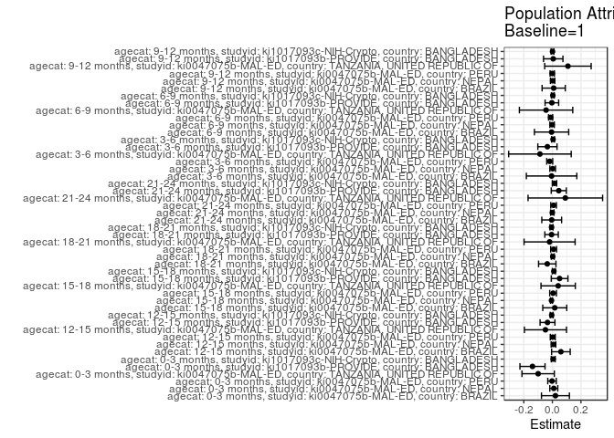

## Results Table

### Parameter: TSM

| agecat | studyid | country | intervention_level | baseline_level | estimate | ci_lower | ci_upper |
| --- | --- | --- | --- | --- | --- | --- | --- |
| 0-3 months | ki0047075b-MAL-ED | BRAZIL | 1 | NA | 1.0571119 | 0.9639544 | 1.1502693 |
| 0-3 months | ki0047075b-MAL-ED | BRAZIL | 0 | NA | 1.0892091 | 1.0319559 | 1.1464624 |
| 0-3 months | ki0047075b-MAL-ED | NEPAL | 1 | NA | 0.9394013 | 0.8891243 | 0.9896784 |
| 0-3 months | ki0047075b-MAL-ED | NEPAL | 0 | NA | 1.0166734 | 0.8660202 | 1.1673266 |
| 0-3 months | ki0047075b-MAL-ED | PERU | 1 | NA | 0.9350193 | 0.8795364 | 0.9905021 |
| 0-3 months | ki0047075b-MAL-ED | PERU | 0 | NA | 0.9353978 | 0.7881984 | 1.0825973 |
| 0-3 months | ki0047075b-MAL-ED | TANZANIA, UNITED REPUBLIC OF | 1 | NA | 1.0002689 | 0.8901714 | 1.1103664 |
| 0-3 months | ki0047075b-MAL-ED | TANZANIA, UNITED REPUBLIC OF | 0 | NA | 0.8836569 | 0.8111346 | 0.9561791 |
| 0-3 months | ki1017093b-PROVIDE | BANGLADESH | 1 | NA | 1.0407492 | 0.9522132 | 1.1292852 |
| 0-3 months | ki1017093b-PROVIDE | BANGLADESH | 0 | NA | 0.8987855 | 0.8838571 | 0.9137140 |
| 0-3 months | ki1017093c-NIH-Crypto | BANGLADESH | 1 | NA | 0.8786528 | 0.8586186 | 0.8986870 |
| 0-3 months | ki1017093c-NIH-Crypto | BANGLADESH | 0 | NA | 0.8959765 | 0.8734148 | 0.9185383 |
| 3-6 months | ki0047075b-MAL-ED | BRAZIL | 1 | NA | 0.5989080 | 0.4058939 | 0.7919221 |
| 3-6 months | ki0047075b-MAL-ED | BRAZIL | 0 | NA | 0.5992296 | 0.5483680 | 0.6500913 |
| 3-6 months | ki0047075b-MAL-ED | NEPAL | 1 | NA | 0.5140043 | 0.4763972 | 0.5516114 |
| 3-6 months | ki0047075b-MAL-ED | NEPAL | 0 | NA | 0.5272786 | 0.4028040 | 0.6517532 |
| 3-6 months | ki0047075b-MAL-ED | PERU | 1 | NA | 0.5212478 | 0.4630299 | 0.5794657 |
| 3-6 months | ki0047075b-MAL-ED | PERU | 0 | NA | 0.4466945 | 0.3713533 | 0.5220356 |
| 3-6 months | ki0047075b-MAL-ED | TANZANIA, UNITED REPUBLIC OF | 1 | NA | 0.5378113 | 0.3002548 | 0.7753678 |
| 3-6 months | ki0047075b-MAL-ED | TANZANIA, UNITED REPUBLIC OF | 0 | NA | 0.4362014 | 0.3434105 | 0.5289923 |
| 3-6 months | ki1017093b-PROVIDE | BANGLADESH | 1 | NA | 0.5236738 | 0.4564325 | 0.5909152 |
| 3-6 months | ki1017093b-PROVIDE | BANGLADESH | 0 | NA | 0.4885744 | 0.4752666 | 0.5018821 |
| 3-6 months | ki1017093c-NIH-Crypto | BANGLADESH | 1 | NA | 0.4933350 | 0.4780550 | 0.5086149 |
| 3-6 months | ki1017093c-NIH-Crypto | BANGLADESH | 0 | NA | 0.5006712 | 0.4843156 | 0.5170268 |
| 6-9 months | ki0047075b-MAL-ED | BRAZIL | 1 | NA | 0.4059320 | 0.2791846 | 0.5326793 |
| 6-9 months | ki0047075b-MAL-ED | BRAZIL | 0 | NA | 0.4033841 | 0.3613252 | 0.4454430 |
| 6-9 months | ki0047075b-MAL-ED | NEPAL | 1 | NA | 0.2703081 | 0.2412994 | 0.2993169 |
| 6-9 months | ki0047075b-MAL-ED | NEPAL | 0 | NA | 0.2627762 | 0.1771564 | 0.3483961 |
| 6-9 months | ki0047075b-MAL-ED | PERU | 1 | NA | 0.2642970 | 0.2287653 | 0.2998286 |
| 6-9 months | ki0047075b-MAL-ED | PERU | 0 | NA | 0.2038537 | 0.1437150 | 0.2639924 |

[output cut: 66 more lines]

### Parameter: E(Y)

| agecat | studyid | country | intervention_level | baseline_level | estimate | ci_lower | ci_upper |
| --- | --- | --- | --- | --- | --- | --- | --- |
| 0-3 months | ki0047075b-MAL-ED | BRAZIL | NA | NA | 1.0785291 | 1.0272897 | 1.1297685 |
| 0-3 months | ki0047075b-MAL-ED | NEPAL | NA | NA | 0.9493726 | 0.9004043 | 0.9983408 |
| 0-3 months | ki0047075b-MAL-ED | PERU | NA | NA | 0.9326347 | 0.8810468 | 0.9842227 |
| 0-3 months | ki0047075b-MAL-ED | TANZANIA, UNITED REPUBLIC OF | NA | NA | 0.9007220 | 0.8354879 | 0.9659562 |
| 0-3 months | ki1017093b-PROVIDE | BANGLADESH | NA | NA | 0.9016472 | 0.8868914 | 0.9164029 |
| 0-3 months | ki1017093c-NIH-Crypto | BANGLADESH | NA | NA | 0.8845220 | 0.8699746 | 0.8990694 |
| 3-6 months | ki0047075b-MAL-ED | BRAZIL | NA | NA | 0.5934783 | 0.5435445 | 0.6434121 |
| 3-6 months | ki0047075b-MAL-ED | NEPAL | NA | NA | 0.5160486 | 0.4804683 | 0.5516290 |
| 3-6 months | ki0047075b-MAL-ED | PERU | NA | NA | 0.5026377 | 0.4533571 | 0.5519182 |
| 3-6 months | ki0047075b-MAL-ED | TANZANIA, UNITED REPUBLIC OF | NA | NA | 0.4507171 | 0.3635622 | 0.5378720 |
| 3-6 months | ki1017093b-PROVIDE | BANGLADESH | NA | NA | 0.4890611 | 0.4760060 | 0.5021163 |
| 3-6 months | ki1017093c-NIH-Crypto | BANGLADESH | NA | NA | 0.4980544 | 0.4869892 | 0.5091196 |
| 6-9 months | ki0047075b-MAL-ED | BRAZIL | NA | NA | 0.4002611 | 0.3612162 | 0.4393059 |
| 6-9 months | ki0047075b-MAL-ED | NEPAL | NA | NA | 0.2683270 | 0.2401434 | 0.2965106 |
| 6-9 months | ki0047075b-MAL-ED | PERU | NA | NA | 0.2520055 | 0.2213895 | 0.2826214 |
| 6-9 months | ki0047075b-MAL-ED | TANZANIA, UNITED REPUBLIC OF | NA | NA | 0.2253405 | 0.1374776 | 0.3132034 |
| 6-9 months | ki1017093b-PROVIDE | BANGLADESH | NA | NA | 0.2491653 | 0.2371134 | 0.2612172 |
| 6-9 months | ki1017093c-NIH-Crypto | BANGLADESH | NA | NA | 0.2675097 | 0.2569518 | 0.2780676 |
| 9-12 months | ki0047075b-MAL-ED | BRAZIL | NA | NA | 0.2831198 | 0.2443371 | 0.3219026 |
| 9-12 months | ki0047075b-MAL-ED | NEPAL | NA | NA | 0.1905809 | 0.1625784 | 0.2185835 |
| 9-12 months | ki0047075b-MAL-ED | PERU | NA | NA | 0.1997749 | 0.1642326 | 0.2353171 |
| 9-12 months | ki0047075b-MAL-ED | TANZANIA, UNITED REPUBLIC OF | NA | NA | 0.1329811 | 0.0819697 | 0.1839925 |
| 9-12 months | ki1017093b-PROVIDE | BANGLADESH | NA | NA | 0.1775316 | 0.1681968 | 0.1868664 |
| 9-12 months | ki1017093c-NIH-Crypto | BANGLADESH | NA | NA | 0.1978449 | 0.1874487 | 0.2082411 |
| 12-15 months | ki0047075b-MAL-ED | BRAZIL | NA | NA | 0.2016949 | 0.1703194 | 0.2330704 |
| 12-15 months | ki0047075b-MAL-ED | NEPAL | NA | NA | 0.1416418 | 0.1110034 | 0.1722801 |
| 12-15 months | ki0047075b-MAL-ED | PERU | NA | NA | 0.1424940 | 0.1030357 | 0.1819523 |
| 12-15 months | ki0047075b-MAL-ED | TANZANIA, UNITED REPUBLIC OF | NA | NA | 0.2041939 | 0.1491943 | 0.2591935 |
| 12-15 months | ki1017093b-PROVIDE | BANGLADESH | NA | NA | 0.1800324 | 0.1683272 | 0.1917375 |
| 12-15 months | ki1017093c-NIH-Crypto | BANGLADESH | NA | NA | 0.1640603 | 0.1535198 | 0.1746008 |
| 15-18 months | ki0047075b-MAL-ED | BRAZIL | NA | NA | 0.2121519 | 0.1722209 | 0.2520830 |
| 15-18 months | ki0047075b-MAL-ED | NEPAL | NA | NA | 0.1744053 | 0.1523126 | 0.1964979 |
| 15-18 months | ki0047075b-MAL-ED | PERU | NA | NA | 0.1396329 | 0.0961677 | 0.1830980 |
| 15-18 months | ki0047075b-MAL-ED | TANZANIA, UNITED REPUBLIC OF | NA | NA | 0.1088672 | 0.0551896 | 0.1625448 |
| 15-18 months | ki1017093b-PROVIDE | BANGLADESH | NA | NA | 0.1563514 | 0.1445823 | 0.1681205 |
| 15-18 months | ki1017093c-NIH-Crypto | BANGLADESH | NA | NA | 0.1611973 | 0.1506617 | 0.1717329 |
| 18-21 months | ki0047075b-MAL-ED | BRAZIL | NA | NA | 0.1613623 | 0.1290425 | 0.1936822 |
| 18-21 months | ki0047075b-MAL-ED | NEPAL | NA | NA | 0.1854094 | 0.1617682 | 0.2090505 |
| 18-21 months | ki0047075b-MAL-ED | PERU | NA | NA | 0.1970640 | 0.1585526 | 0.2355754 |
| 18-21 months | ki0047075b-MAL-ED | TANZANIA, UNITED REPUBLIC OF | NA | NA | 0.1748513 | 0.1157560 | 0.2339466 |
| 18-21 months | ki1017093b-PROVIDE | BANGLADESH | NA | NA | 0.1324882 | 0.1210438 | 0.1439326 |
| 18-21 months | ki1017093c-NIH-Crypto | BANGLADESH | NA | NA | 0.1426609 | 0.1319333 | 0.1533885 |
| 21-24 months | ki0047075b-MAL-ED | BRAZIL | NA | NA | 0.1492836 | 0.1183710 | 0.1801961 |
| 21-24 months | ki0047075b-MAL-ED | NEPAL | NA | NA | 0.1643936 | 0.1387769 | 0.1900103 |
| 21-24 months | ki0047075b-MAL-ED | PERU | NA | NA | 0.1753485 | 0.1374186 | 0.2132784 |
| 21-24 months | ki0047075b-MAL-ED | TANZANIA, UNITED REPUBLIC OF | NA | NA | 0.1191438 | 0.0472705 | 0.1910171 |
| 21-24 months | ki1017093b-PROVIDE | BANGLADESH | NA | NA | 0.1419705 | 0.1305335 | 0.1534075 |
| 21-24 months | ki1017093c-NIH-Crypto | BANGLADESH | NA | NA | 0.1750500 | 0.1624914 | 0.1876087 |

### Parameter: ATE

| agecat | studyid | country | intervention_level | baseline_level | estimate | ci_lower | ci_upper |
| --- | --- | --- | --- | --- | --- | --- | --- |
| 0-3 months | ki0047075b-MAL-ED | BRAZIL | 1 | 1 | 0.0000000 | 0.0000000 | 0.0000000 |
| 0-3 months | ki0047075b-MAL-ED | BRAZIL | 0 | 1 | 0.0320972 | -0.0787242 | 0.1429187 |
| 0-3 months | ki0047075b-MAL-ED | NEPAL | 1 | 1 | 0.0000000 | 0.0000000 | 0.0000000 |
| 0-3 months | ki0047075b-MAL-ED | NEPAL | 0 | 1 | 0.0772721 | -0.0820552 | 0.2365994 |
| 0-3 months | ki0047075b-MAL-ED | PERU | 1 | 1 | 0.0000000 | 0.0000000 | 0.0000000 |
| 0-3 months | ki0047075b-MAL-ED | PERU | 0 | 1 | 0.0003786 | -0.1569451 | 0.1577023 |
| 0-3 months | ki0047075b-MAL-ED | TANZANIA, UNITED REPUBLIC OF | 1 | 1 | 0.0000000 | 0.0000000 | 0.0000000 |
| 0-3 months | ki0047075b-MAL-ED | TANZANIA, UNITED REPUBLIC OF | 0 | 1 | -0.1166120 | -0.2484488 | 0.0152248 |
| 0-3 months | ki1017093b-PROVIDE | BANGLADESH | 1 | 1 | 0.0000000 | 0.0000000 | 0.0000000 |
| 0-3 months | ki1017093b-PROVIDE | BANGLADESH | 0 | 1 | -0.1419637 | -0.2319665 | -0.0519609 |
| 0-3 months | ki1017093c-NIH-Crypto | BANGLADESH | 1 | 1 | 0.0000000 | 0.0000000 | 0.0000000 |
| 0-3 months | ki1017093c-NIH-Crypto | BANGLADESH | 0 | 1 | 0.0173237 | -0.0126213 | 0.0472688 |
| 3-6 months | ki0047075b-MAL-ED | BRAZIL | 1 | 1 | 0.0000000 | 0.0000000 | 0.0000000 |
| 3-6 months | ki0047075b-MAL-ED | BRAZIL | 0 | 1 | 0.0003216 | -0.2000203 | 0.2006636 |
| 3-6 months | ki0047075b-MAL-ED | NEPAL | 1 | 1 | 0.0000000 | 0.0000000 | 0.0000000 |
| 3-6 months | ki0047075b-MAL-ED | NEPAL | 0 | 1 | 0.0132744 | -0.1167438 | 0.1432925 |
| 3-6 months | ki0047075b-MAL-ED | PERU | 1 | 1 | 0.0000000 | 0.0000000 | 0.0000000 |
| 3-6 months | ki0047075b-MAL-ED | PERU | 0 | 1 | -0.0745533 | -0.1709070 | 0.0218004 |
| 3-6 months | ki0047075b-MAL-ED | TANZANIA, UNITED REPUBLIC OF | 1 | 1 | 0.0000000 | 0.0000000 | 0.0000000 |
| 3-6 months | ki0047075b-MAL-ED | TANZANIA, UNITED REPUBLIC OF | 0 | 1 | -0.1016099 | -0.3566457 | 0.1534259 |
| 3-6 months | ki1017093b-PROVIDE | BANGLADESH | 1 | 1 | 0.0000000 | 0.0000000 | 0.0000000 |
| 3-6 months | ki1017093b-PROVIDE | BANGLADESH | 0 | 1 | -0.0350994 | -0.1037790 | 0.0335801 |
| 3-6 months | ki1017093c-NIH-Crypto | BANGLADESH | 1 | 1 | 0.0000000 | 0.0000000 | 0.0000000 |
| 3-6 months | ki1017093c-NIH-Crypto | BANGLADESH | 0 | 1 | 0.0073362 | -0.0149934 | 0.0296659 |
| 6-9 months | ki0047075b-MAL-ED | BRAZIL | 1 | 1 | 0.0000000 | 0.0000000 | 0.0000000 |
| 6-9 months | ki0047075b-MAL-ED | BRAZIL | 0 | 1 | -0.0025479 | -0.1380207 | 0.1329249 |
| 6-9 months | ki0047075b-MAL-ED | NEPAL | 1 | 1 | 0.0000000 | 0.0000000 | 0.0000000 |
| 6-9 months | ki0047075b-MAL-ED | NEPAL | 0 | 1 | -0.0075319 | -0.0979432 | 0.0828794 |
| 6-9 months | ki0047075b-MAL-ED | PERU | 1 | 1 | 0.0000000 | 0.0000000 | 0.0000000 |
| 6-9 months | ki0047075b-MAL-ED | PERU | 0 | 1 | -0.0604433 | -0.1306932 | 0.0098067 |

[output cut: 66 more lines]

### Parameter: PAR

| agecat | studyid | country | intervention_level | baseline_level | estimate | ci_lower | ci_upper |
| --- | --- | --- | --- | --- | --- | --- | --- |
| 0-3 months | ki0047075b-MAL-ED | BRAZIL | 1 | NA | 0.0214172 | -0.0763216 | 0.1191560 |
| 0-3 months | ki0047075b-MAL-ED | NEPAL | 1 | NA | 0.0099713 | -0.0178778 | 0.0378203 |
| 0-3 months | ki0047075b-MAL-ED | PERU | 1 | NA | -0.0023845 | -0.0322093 | 0.0274403 |
| 0-3 months | ki0047075b-MAL-ED | TANZANIA, UNITED REPUBLIC OF | 1 | NA | -0.0995468 | -0.2128129 | 0.0137193 |
| 0-3 months | ki1017093b-PROVIDE | BANGLADESH | 1 | NA | -0.1391020 | -0.2268869 | -0.0513172 |
| 0-3 months | ki1017093c-NIH-Crypto | BANGLADESH | 1 | NA | 0.0058691 | -0.0079463 | 0.0196846 |
| 3-6 months | ki0047075b-MAL-ED | BRAZIL | 1 | NA | -0.0054297 | -0.1819199 | 0.1710605 |
| 3-6 months | ki0047075b-MAL-ED | NEPAL | 1 | NA | 0.0020443 | -0.0175378 | 0.0216265 |
| 3-6 months | ki0047075b-MAL-ED | PERU | 1 | NA | -0.0186101 | -0.0394695 | 0.0022492 |
| 3-6 months | ki0047075b-MAL-ED | TANZANIA, UNITED REPUBLIC OF | 1 | NA | -0.0870942 | -0.3059671 | 0.1317786 |
| 3-6 months | ki1017093b-PROVIDE | BANGLADESH | 1 | NA | -0.0346127 | -0.1016756 | 0.0324502 |
| 3-6 months | ki1017093c-NIH-Crypto | BANGLADESH | 1 | NA | 0.0047194 | -0.0057131 | 0.0151519 |
| 6-9 months | ki0047075b-MAL-ED | BRAZIL | 1 | NA | -0.0056709 | -0.1255541 | 0.1142122 |
| 6-9 months | ki0047075b-MAL-ED | NEPAL | 1 | NA | -0.0019811 | -0.0175220 | 0.0135597 |
| 6-9 months | ki0047075b-MAL-ED | PERU | 1 | NA | -0.0122915 | -0.0267257 | 0.0021427 |
| 6-9 months | ki0047075b-MAL-ED | TANZANIA, UNITED REPUBLIC OF | 1 | NA | -0.0440499 | -0.2307706 | 0.1426708 |
| 6-9 months | ki1017093b-PROVIDE | BANGLADESH | 1 | NA | -0.0034927 | -0.0510025 | 0.0440171 |
| 6-9 months | ki1017093c-NIH-Crypto | BANGLADESH | 1 | NA | 0.0031307 | -0.0069900 | 0.0132515 |
| 9-12 months | ki0047075b-MAL-ED | BRAZIL | 1 | NA | 0.0091666 | -0.0719509 | 0.0902842 |
| 9-12 months | ki0047075b-MAL-ED | NEPAL | 1 | NA | 0.0017623 | -0.0133960 | 0.0169206 |
| 9-12 months | ki0047075b-MAL-ED | PERU | 1 | NA | -0.0008294 | -0.0160615 | 0.0144027 |
| 9-12 months | ki0047075b-MAL-ED | TANZANIA, UNITED REPUBLIC OF | 1 | NA | 0.1087821 | -0.0538143 | 0.2713786 |
| 9-12 months | ki1017093b-PROVIDE | BANGLADESH | 1 | NA | 0.0060363 | -0.0618434 | 0.0739160 |
| 9-12 months | ki1017093c-NIH-Crypto | BANGLADESH | 1 | NA | 0.0011136 | -0.0087392 | 0.0109663 |
| 12-15 months | ki0047075b-MAL-ED | BRAZIL | 1 | NA | 0.0594755 | -0.0057183 | 0.1246692 |
| 12-15 months | ki0047075b-MAL-ED | NEPAL | 1 | NA | 0.0078140 | -0.0083206 | 0.0239486 |
| 12-15 months | ki0047075b-MAL-ED | PERU | 1 | NA | 0.0026498 | -0.0146525 | 0.0199521 |
| 12-15 months | ki0047075b-MAL-ED | TANZANIA, UNITED REPUBLIC OF | 1 | NA | -0.0483574 | -0.1955965 | 0.0988818 |
| 12-15 months | ki1017093b-PROVIDE | BANGLADESH | 1 | NA | -0.0340704 | -0.0859176 | 0.0177769 |
| 12-15 months | ki1017093c-NIH-Crypto | BANGLADESH | 1 | NA | -0.0047713 | -0.0150925 | 0.0055498 |
| 15-18 months | ki0047075b-MAL-ED | BRAZIL | 1 | NA | 0.0167622 | -0.0672008 | 0.1007253 |
| 15-18 months | ki0047075b-MAL-ED | NEPAL | 1 | NA | -0.0061912 | -0.0132051 | 0.0008226 |
| 15-18 months | ki0047075b-MAL-ED | PERU | 1 | NA | 0.0049735 | -0.0184942 | 0.0284411 |
| 15-18 months | ki0047075b-MAL-ED | TANZANIA, UNITED REPUBLIC OF | 1 | NA | 0.0404729 | -0.0795337 | 0.1604795 |
| 15-18 months | ki1017093b-PROVIDE | BANGLADESH | 1 | NA | 0.0505147 | -0.0078526 | 0.1088821 |
| 15-18 months | ki1017093c-NIH-Crypto | BANGLADESH | 1 | NA | 0.0104744 | -0.0005338 | 0.0214825 |
| 18-21 months | ki0047075b-MAL-ED | BRAZIL | 1 | NA | -0.0356822 | -0.0964637 | 0.0250993 |
| 18-21 months | ki0047075b-MAL-ED | NEPAL | 1 | NA | 0.0026577 | -0.0076567 | 0.0129720 |
| 18-21 months | ki0047075b-MAL-ED | PERU | 1 | NA | 0.0088029 | -0.0116542 | 0.0292600 |
| 18-21 months | ki0047075b-MAL-ED | TANZANIA, UNITED REPUBLIC OF | 1 | NA | -0.0194905 | -0.1980579 | 0.1590769 |
| 18-21 months | ki1017093b-PROVIDE | BANGLADESH | 1 | NA | -0.0056075 | -0.0526123 | 0.0413974 |
| 18-21 months | ki1017093c-NIH-Crypto | BANGLADESH | 1 | NA | -0.0058200 | -0.0168228 | 0.0051828 |
| 21-24 months | ki0047075b-MAL-ED | BRAZIL | 1 | NA | -0.0047345 | -0.0740528 | 0.0645838 |
| 21-24 months | ki0047075b-MAL-ED | NEPAL | 1 | NA | -0.0004322 | -0.0123950 | 0.0115306 |
| 21-24 months | ki0047075b-MAL-ED | PERU | 1 | NA | 0.0085267 | -0.0110943 | 0.0281477 |
| 21-24 months | ki0047075b-MAL-ED | TANZANIA, UNITED REPUBLIC OF | 1 | NA | 0.0907535 | -0.1700304 | 0.3515373 |
| 21-24 months | ki1017093b-PROVIDE | BANGLADESH | 1 | NA | 0.0447667 | -0.0079738 | 0.0975072 |
| 21-24 months | ki1017093c-NIH-Crypto | BANGLADESH | 1 | NA | 0.0149499 | -0.0003314 | 0.0302312 |